# Expected Hits

Jim Albert

2023-01-25

### January 26 meeting

The goal here is to explore the idea of expected hits and expected batting average.

Here’s a blog post on the topic that you can read:

https://bayesball.github.io/BLOG/BAVG.html#expected-batting-average-and-hits-added

### Data

Statcast measures launch angle (degrees) and exit velocity (mph) of each ball put into play.

Statcast also measures the location of the batted ball on the field from which you can compute a spray angle.

We read in Statcast in-play data from the 2022 season.

```r
library(readr)
scip <- read_csv("https://raw.githubusercontent.com/bayesball/HUGO/main/January%2026/sc2022_ip.csv")
```

This dataset has seven variables:

```r
spec(scip)
```

[output not shown]

### Explore launch angles and exit velocities

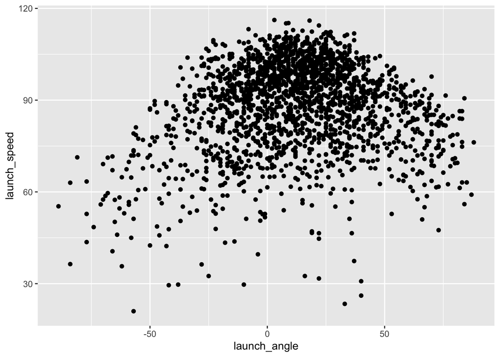

```r
library(ggplot2)
library(dplyr)
ggplot(sample_n(scip, size = 2000),
       aes(launch_angle, launch_speed)) +
  geom_point()
```

If launch angle < 10, ground ball if launch angle is in (10, 25), line drive if launch angle is in (25, 50), fly ball if launch angle is over 50, pop up

### Launch variables and hits

Balls hit with suitable values of LA and LS tend to be hits.

```r
hits <- c("single", "double", "triple", "home_run")
```

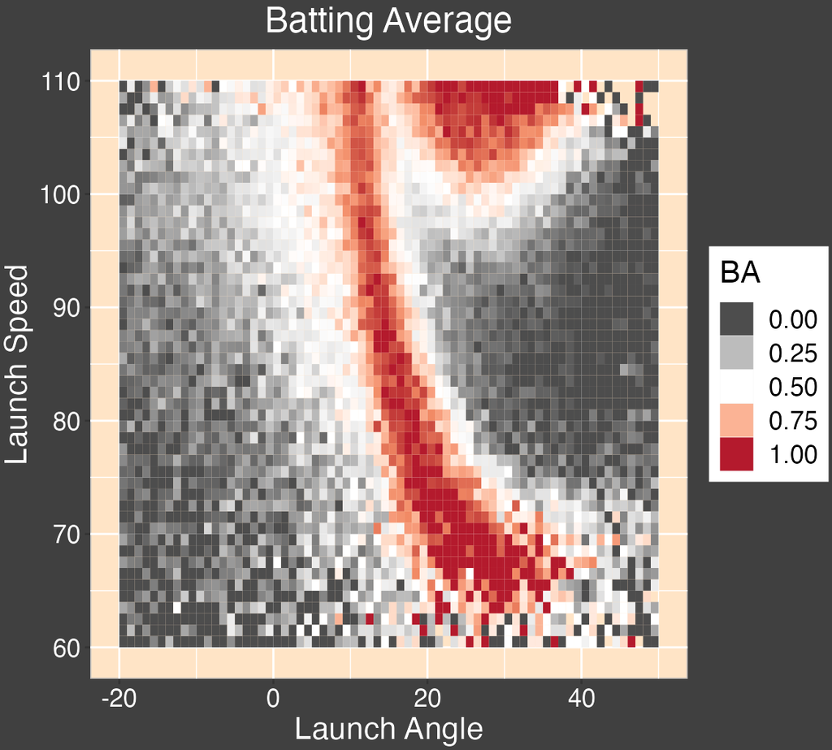

Relate to the type of batted ball (ground ball, line drive, fly ball, pop up).

### Expected Batting Average

Statcast data has a variable `estimated_ba_using_speedangle` which estimates the probability of a hit for a batted ball given the LA and LS measurements.

```r
scip[1200, ]
```

```
## # A tibble: 1 × 7
##   batter pitcher launch_angle launch_speed events estimated_ba_using_s…¹ estim…²
##    <dbl>   <dbl>        <dbl>        <dbl> <chr>                   <dbl>   <dbl>
## 1 660670  571578           12         95.7 single                  0.889   0.861
## # … with abbreviated variable names ¹estimated_ba_using_speedangle,
## #   ²estimated_woba_using_speedangle
```

Define

- H = hits
- BIP = balls in play
- xH = expected hits
- xBA = expected batting average (on balls in play)

$$xBA = \frac{xH}{BIP}$$

- HA = hits added = H - xH

Compute for each hitter in the 2022 season H, xH, BA, xBA, HA.

option-command-i

define a hit variable

```r
scip %>%
  mutate(hit = ifelse(events %in% hits, 1, 0)) -> scip
```

```r
head(scip)
```

```
## # A tibble: 6 × 8
##   batter pitcher launch_angle launch_speed events    estimated_b…¹ estim…²   hit
##    <dbl>   <dbl>        <dbl>        <dbl> <chr>             <dbl>   <dbl> <dbl>
## 1 572233  506433           65         82.8 field_out         0.006   0.005     0
## 2 622110  664285          -42         63.9 single            0.14    0.126     1
## 3 614177  425844            9         95.9 single            0.643   0.598     1
## 4 621566  641816            6        113   field_out         0.72    0.687     0
## 5 571657  608331           32         69.7 single            0.783   0.783     1
## 6 575929  669203           64         92.4 field_out         0.009   0.009     0
## # … with abbreviated variable names ¹estimated_ba_using_speedangle,
## #   ²estimated_woba_using_speedangle
```

```r
scip %>%
  group_by(batter) %>%
  summarize(BIP = n(),
            H = sum(hit),
            EH = sum(estimated_ba_using_speedangle)) %>%
  mutate(BA = H / BIP,
         EBA = EH / BIP,
         HA = H - EH) ->
  S
```

```r
head(S)
```

```
## # A tibble: 6 × 7
##   batter   BIP     H    EH    BA   EBA    HA
##    <dbl> <int> <dbl> <dbl> <dbl> <dbl> <dbl>
## 1 405395   258    83  85.5 0.322 0.332 -2.54
## 2 408234   299   101  98.9 0.338 0.331  2.11
## 3 425877   223    56  63.4 0.251 0.284 -7.43
## 4 429664    75    15  21.9 0.2   0.292 -6.87
## 5 435559   113    25  27.7 0.221 0.245 -2.66
## 6 443558   328   105 111.  0.320 0.337 -5.65
```

1. Which batter has the highest hits added?
2. Which batter has the lowest hits added?

```r
S %>%
  arrange(desc(HA)) -> S
```

Here are the top ones:

The top one is Goldschmidt.

```r
head(S)
```

```
## # A tibble: 6 × 7
##   batter   BIP     H    EH    BA   EBA    HA
##    <dbl> <int> <dbl> <dbl> <dbl> <dbl> <dbl>
## 1 502671   422   177  147. 0.419 0.349  29.6
## 2 593428   444   169  144. 0.381 0.324  24.9
## 3 643446   477   174  150. 0.365 0.315  23.9
## 4 668227   429   153  132. 0.357 0.308  20.9
## 5 665926   386   145  125. 0.376 0.323  20.4
## 6 677594   363   143  124. 0.394 0.340  19.5
```

```r
tail(S)
```

```
## # A tibble: 6 × 7
##   batter   BIP     H    EH    BA   EBA    HA
##    <dbl> <int> <dbl> <dbl> <dbl> <dbl> <dbl>
## 1 624428   477   129  144. 0.270 0.302 -15.0
## 2 608385   355   100  115. 0.282 0.325 -15.2
## 3 663624   404   137  153. 0.339 0.378 -15.6
## 4 642133   409   116  137. 0.284 0.335 -21.2
## 5 467793   345    87  111. 0.252 0.322 -24.1
## 6 608369   493   144  169. 0.292 0.343 -25.3
```

Corey Segar is the bottom – wonder why?